# Warm-up 04: Exploring NBA Data

Cindy Lo

9/23/2018

```r
mkdir warmup04
cd warmup04
curl -O https://raw.githubusercontent.com/ucb-stat133/stat133-fall-2018/master/data/nba2018.csv
```

## 1) Import the data in R

```r
#install.packages("readr")
library(readr)

nba2018_tbl <- read_csv("nba2018.csv", col_types = list(player = col_character(), team = col_character(), height = col_character(), birth_date = col_character(), country = col_character(), experience = col_character(), college = col_character(), position = col_factor(levels = c("C", "PF", "PG", "SF", "SG")), salary = col_double(), field_goals_perc = col_double(), points3_perc = col_double(), points2_perc = col_double(), points1_perc = col_double(), effective_field_goal_perc = col_double()))

str(nba2018_tbl)
```

```
## Classes 'tbl_df', 'tbl' and 'data.frame':    477 obs. of  38 variables:
##  $ player                   : chr  "Al Horford" "Amir Johnson" "Avery Bradley" "Demetrius Jackson" ...
##  $ number                   : chr  "42" "90" "0" "9" ...
##  $ team                     : chr  "BOS" "BOS" "BOS" "BOS" ...
##  $ position                 : Factor w/ 5 levels "C","PF","PG",..: 1 2 5 3 4 3 4 5 4 2 ...
##  $ height                   : chr  "6-10" "6-9" "6-2" "6-1" ...
##  $ weight                   : int  245 240 180 201 205 185 235 215 225 231 ...
##  $ birth_date               : chr  "June 3, 1986" "May 1, 1987" "November 26, 1990" "September 7, 1994" ...
##  $ country                  : chr  "do" "us" "us" "us" ...
##  $ experience               : chr  "9" "11" "6" "R" ...
##  $ college                  : chr  "University of Florida" NA "University of Texas at Austin" "University of Notre Dame" ...
##  $ salary                   : num  26540100 12000000 8269663 1450000 1410598 ...
##  $ rank                     : int  4 6 5 15 11 1 3 13 8 10 ...
##  $ age                      : int  30 29 26 22 31 27 26 21 20 29 ...
##  $ games                    : int  68 80 55 5 47 76 72 29 78 78 ...
##  $ games_started            : int  68 77 55 0 0 76 72 0 20 6 ...
##  $ minutes                  : int  2193 1608 1835 17 538 2569 2335 220 1341 1232 ...
##  $ field_goals              : int  379 213 359 3 95 682 333 25 192 114 ...
##  $ field_goals_atts         : int  801 370 775 4 232 1473 720 58 423 262 ...
##  $ field_goals_perc         : num  0.473 0.576 0.463 0.75 0.409 0.463 0.463 0.431 0.454 0.435 ...
##  $ points3                  : int  86 27 108 1 39 245 157 12 46 45 ...
##  $ points3_atts             : int  242 66 277 1 111 646 394 35 135 130 ...
##  $ points3_perc             : num  0.355 0.409 0.39 1 0.351 0.379 0.398 0.343 0.341 0.346 ...
##  $ points2                  : int  293 186 251 2 56 437 176 13 146 69 ...
##  $ points2_atts             : int  559 304 498 3 121 827 326 23 288 132 ...
##  $ points2_perc             : num  0.524 0.612 0.504 0.667 0.463 0.528 0.54 0.565 0.507 0.523 ...
##  $ effective_field_goal_perc: num  0.527 0.612 0.533 0.875 0.494 0.546 0.572 0.534 0.508 0.521 ...
##  $ points1                  : int  108 67 68 3 33 590 176 6 85 26 ...
##  $ points1_atts             : int  135 100 93 6 41 649 217 9 124 37 ...
##  $ points1_perc             : num  0.8 0.67 0.731 0.5 0.805 0.909 0.811 0.667 0.685 0.703 ...
##  $ off_rebounds             : int  95 118 65 2 16 43 48 6 45 59 ...
##  $ def_rebounds             : int  370 248 269 2 68 162 367 20 175 213 ...
##  $ total_rebounds           : int  465 366 334 4 84 205 415 26 220 272 ...
##  $ assists                  : int  337 140 122 3 33 448 155 4 64 71 ...
##  $ steals                   : int  52 51 68 0 9 70 73 10 35 25 ...
##  $ blocks                   : int  86 62 11 0 7 13 23 2 18 17 ...
##  $ turnovers                : int  115 77 88 0 25 210 80 4 68 39 ...
##  $ fouls                    : int  138 211 141 0 48 167 161 15 142 122 ...
##  $ points                   : int  952 520 894 10 262 2199 999 68 515 299 ...
##  - attr(*, "spec")=List of 2
```

[output cut: 68 more lines]

[output not shown]

## 2) Right after importing data

```r
experience <- nba2018_tbl$experience
experience[experience == "R"] = "0"
experience <- as.integer(experience)
summary(experience)
```

```
##    Min. 1st Qu.  Median    Mean 3rd Qu.    Max.
##   0.000   1.000   4.000   4.662   7.000  18.000
```

```r
salary <- nba2018_tbl$salary
salary <- salary / 1000000
summary(salary)
```

```
##      Min.   1st Qu.    Median      Mean   3rd Qu.      Max.
##  0.005145  1.050961  3.000000  5.804697  8.269663 30.963450
```

```r
position <- nba2018_tbl$position
levels(position) <- c("center", "power_fwd", "point_guard", "small_fwd", "shoot_guard")
table(position)
```

```
## position
##      center   power_fwd point_guard   small_fwd shoot_guard
##          97          98          96          84         102
```

## 3) A bit of subscripting (i.e. indexing, slicing, subsetting)

How many players went to UCLA?

```r
length(nba2018_tbl$college[which(nba2018_tbl$college == "University of California, Los Angeles")])
```

```
## [1] 14
```

How many players went to Cal?

```r
length(nba2018_tbl$college[which(nba2018_tbl$college == "University of California, Berkeley")])
```

```
## [1] 0
```

What’s the largest weight value?

```r
max(nba2018_tbl$weight)
```

```
## [1] 290
```

Who are the players with the largest weight value?

```r
nba2018_tbl$player[which(nba2018_tbl$weight == max(nba2018_tbl$weight))]
```

```
## [1] "Boban Marjanovic"
```

What’s the overall average weight?

```r
mean(nba2018_tbl$weight)
```

```
## [1] 219.9119
```

What is the median salary of all players?

```r
median(nba2018_tbl$salary)
```

```
## [1] 3e+06
```

```r
median(salary) #median using salary in millions
```

```
## [1] 3
```

What is the median salary of the players with 10 years of experience or more?

```r
median(nba2018_tbl$salary[which(nba2018_tbl$experience > 10 | nba2018_tbl$experience == 10)])
```

```
## [1] 3678319
```

```r
median(salary[which(nba2018_tbl$experience > 10 | nba2018_tbl$experience == 10)]) #median using salary in millions
```

```
## [1] 3.678319
```

What is the median salary of Shooting Guards and Point Guards?

```r
median(nba2018_tbl$salary[which(nba2018_tbl$position == "SG" | nba2018_tbl$position == "PG")])
```

```
## [1] 2789698
```

```r
median(salary[which(nba2018_tbl$position == "SG" | nba2018_tbl$position == "PG")]) #median using salary in millions
```

```
## [1] 2.789697
```

What is the median salary of Power Forwards, 30 years or older, weighing 240 pounds or more?

```r
median(nba2018_tbl$salary[which(nba2018_tbl$position == "PF" & (nba2018_tbl$age == 30 | nba2018_tbl$age > 30) & (nba2018_tbl$weight == 240 | nba2018_tbl$weight > 240))])
```

```
## [1] 8e+06
```

```r
median(salary[which(nba2018_tbl$position == "PF" & (nba2018_tbl$age == 30 | nba2018_tbl$age > 30) & (nba2018_tbl$weight == 240 | nba2018_tbl$weight > 240))]) #median using salary in millions
```

```
## [1] 8
```

```r
gsw <- data.frame(nba2018_tbl$player, nba2018_tbl$position, nba2018_tbl$height, nba2018_tbl$weight, nba2018_tbl$age)
gsw
```

```
##           nba2018_tbl.player nba2018_tbl.position nba2018_tbl.height
## 1                 Al Horford                    C               6-10
## 2               Amir Johnson                   PF                6-9
## 3              Avery Bradley                   SG                6-2
## 4          Demetrius Jackson                   PG                6-1
## 5               Gerald Green                   SF                6-7
## 6              Isaiah Thomas                   PG                5-9
## 7                Jae Crowder                   SF                6-6
## 8                James Young                   SG                6-6
## 9               Jaylen Brown                   SF                6-7
## 10             Jonas Jerebko                   PF               6-10
## 11             Jordan Mickey                   PF                6-8
## 12              Kelly Olynyk                    C                7-0
## 13              Marcus Smart                   SG                6-4
## 14              Terry Rozier                   PG                6-2
```

[output cut: 941 more lines]

## 4) Performance of players

```r
nba2018_tbl$missed_field_goals = nba2018_tbl$field_goals_atts - nba2018_tbl$field_goals

nba2018_tbl$missed_free_throws = nba2018_tbl$points1_atts - nba2018_tbl$points1

nba2018_tbl$total_rebounds = nba2018_tbl$off_rebounds + nba2018_tbl$def_rebounds

nba2018_tbl$mins_game = nba2018_tbl$minutes / nba2018_tbl$games
```

Calculating efficiency for each player:

```r
PTS <- nba2018_tbl$points1 + nba2018_tbl$points2 + nba2018_tbl$points3
REB <- nba2018_tbl$total_rebounds
AST <- nba2018_tbl$assists
STL <- nba2018_tbl$steals
BLK <- nba2018_tbl$blocks
MissedFG <- nba2018_tbl$missed_field_goals
MissedFT <- nba2018_tbl$missed_free_throws
TO <- nba2018_tbl$turnovers
GP <- nba2018_tbl$games
EFF <- (PTS + REB + AST + STL + BLK - MissedFG - MissedFT - TO) / GP

nba2018_tbl$efficiency = EFF
summary(nba2018_tbl$efficiency)
```

```
##    Min. 1st Qu.  Median    Mean 3rd Qu.    Max.
## -0.6667  2.7692  4.7143  5.6588  7.7089 21.1852
```

[figure not shown]

```r
hist(nba2018_tbl$efficiency, xlab = "Efficiency", ylab = "Number of Players", col = "orange", main = "Efficiency v.s. Number of GSW Players ")
```

Top 10 players by EFF in decreasing order:

```r
sortednba <- nba2018_tbl[order(-nba2018_tbl$efficiency),]
head(sortednba[c("player", "team", "salary", "efficiency")], n = 10)
```

```
## # A tibble: 10 x 4
##    player                team    salary efficiency
##    <chr>                 <chr>    <dbl>      <dbl>
##  1 Russell Westbrook     OKC   26540100       21.2
##  2 James Harden          HOU   26540100       20.8
##  3 Anthony Davis         NOP   22116750       20.3
##  4 Rudy Gobert           UTA    2121288       19.7
##  5 Giannis Antetokounmpo MIL    2995421       19.6
##  6 Kevin Durant          GSW   26540100       19.4
##  7 LeBron James          CLE   30963450       19.3
##  8 Karl-Anthony Towns    MIN    5960160       19.3
##  9 DeAndre Jordan        LAC   21165675       18.7
## 10 Hassan Whiteside      MIA   22116750       18.3
```

Players with a negative EFF:

```r
nba2018_tbl$player[nba2018_tbl$efficiency < 0]
```

```
## [1] "Gary Neal"       "Axel Toupane"    "Michael Gbinije" "Patricio Garino"
## [5] "Ben Bentil"
```

## 5) Further Exploration

The more efficient a player is, the higher his salary?

```r
cor(nba2018_tbl$efficiency, nba2018_tbl$salary)
```

```
## [1] 0.6162854
```

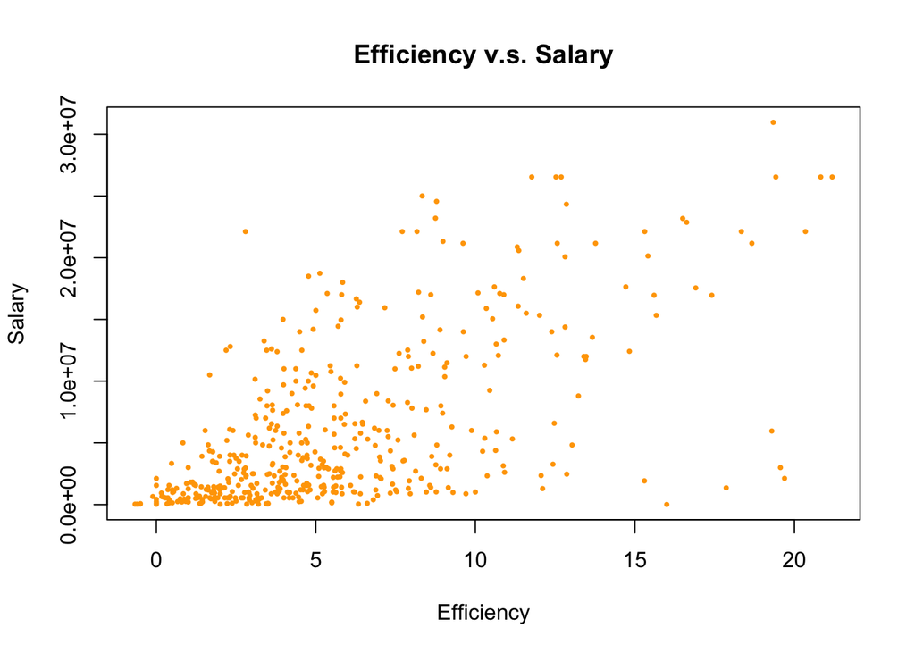

```r
plot(nba2018_tbl$efficiency, nba2018_tbl$salary, main = "Efficiency v.s. Salary", xlab = "Efficiency", ylab = "Salary", col = "orange", pch = 19, cex = 0.4)
```

- There seems to be a general positive trend, as evidenced by the positive correlation and the plot between salary and efficiency.

As players get older, do they tend to become more efficient?

```r
cor(nba2018_tbl$age, nba2018_tbl$efficiency)
```

```
## [1] 0.04014534
```

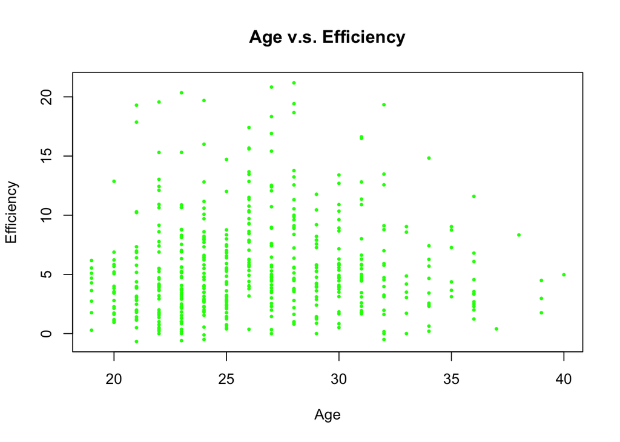

```r
plot(nba2018_tbl$age, nba2018_tbl$efficiency, main = "Age v.s. Efficiency", xlab = "Age", ylab = "Efficiency", col = "green", pch = 19, cex = 0.4)
```

- There doesn’t seem to be any particular relationship between a player’s age and efficiency, and seem to be generally unrelated with each other.

Does the rank of a player seem to be associated with his efficiency?

```r
cor(nba2018_tbl$rank, nba2018_tbl$efficiency)
```

```
## [1] -0.6364901
```

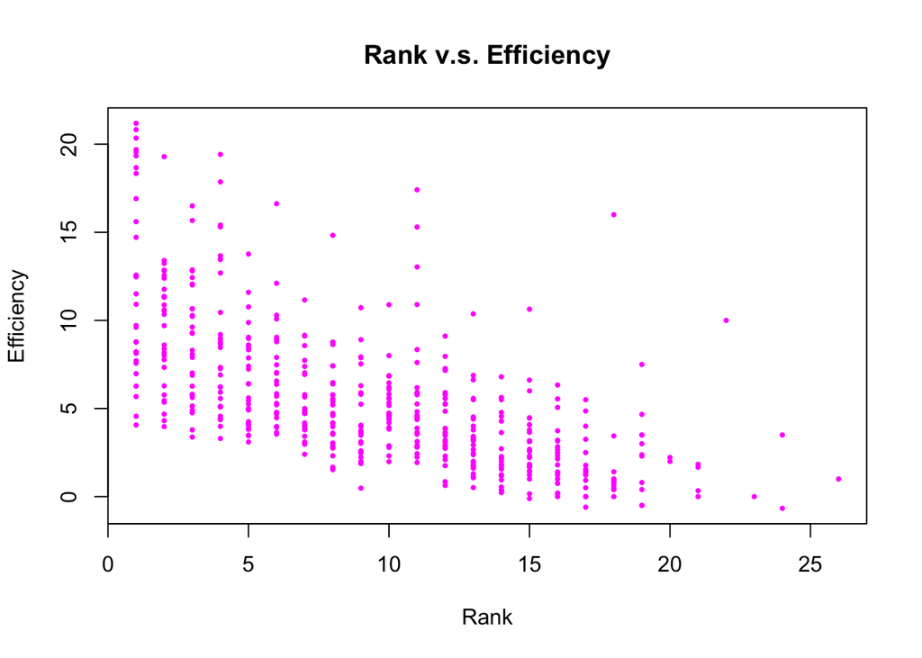

```r
plot(nba2018_tbl$rank, nba2018_tbl$efficiency, main = "Rank v.s. Efficiency", xlab = "Rank", ylab = "Efficiency", col = "magenta", pch = 19, cex = 0.4)
```

- There is an association between a player’s rank and his efficiency. The lower the ranking (aka the larger the number), the lower the efficiency; and the more important the rank, the more efficient the player appears to be.

## 6) Comments and Reflections

What things were hard, even though you saw them in class?

- Even though I saw Prof use `read.table` and `read.csv` in lecture, I still found it hard to import the `nba2018.csv` data file into RStudio, specify the column type, and familiarize myself with the parameters of the function `read_csv`.

What was easy(-ish) even though we haven’t done it in class?

- Working with the subscripting (indexing, slicing, subsetting, etc.) was fairly straight-forward.

Did you need help to complete the assignment? If so, what kind of help? Who helped you?

- I did need help to complete the assignment, especially the part with part 4, the performance of players. I know absolutely nothing about basketball except that you dribble the ball so I asked my friend Cole how the points, field goals, etc. work when calculating efficiency.

How much time did it take to complete this HW?

- It took about 3 hours.

What was the most time consuming part?

- Putting everything into my R Markdown file and making my plots for part 5 were the most time consuming parts of this warm up.

Was there anything that you did not understand? or fully grasped?

- What is the difference between `read.csv` and `read_csv`? As well as other variations of `read.?` or `read_?`
- What’s the difference between a dataframe and a table?

Was there anything frustrating in particular?

- I think importing the data was really frustrating at first, because I was initially using `read.table` and so was writing all of the colClasses manually, until I realized that `read_csv` made things much easier.